# M8 - TP1 : Premiers pas avec Python

Le but du TP est de commencer à étudier de vraies données avec Python. Pour plus de détails sur Python, NumPy et Matplotlib, un grand nombre de ressources sont disponibles sur https://pythonprogramming.net/ , y compris plusieurs séries de vidéos YouTube.

La documentation complète est disponible ici : https://docs.scipy.org/doc/numpy-1.15.0/reference/index.html

## Ex. 0 : Démarrage

Python est un langage très complet et utilisé dans de nombreux domaines, du développement Web à la robotique.

Dans cette série de TP, nous l'utiliserons pour le calcul mathématique et la science des données.

Les bibliothèques de prédilection pour le calcul mathématique en Python sont NumPy et Matplotlib. Commencez par les importer:

```python
%matplotlib inline
import matplotlib.pyplot as plt
import numpy as np
```

## Ex. 1 : Python et NumPy en quelques lignes

1. Calculez $\log(\cos(1-(1+1)/2))$ et $\sqrt{-1}$ avec NumPy

```python
np.log(np.cos(1 - (1 + 1)/2 ))
```

```
0.0
```

```python
x = -1 - 0j  # On crée le complexe -1 + 0j
np.sqrt(x)
```

```
1j
```

1. Que font les instructions Python help et %whos

```python
help(print)
```

```
Help on built-in function print in module builtins:

print(...)
    print(value, ..., sep=' ', end='\n', file=sys.stdout, flush=False)

    Prints the values to a stream, or to sys.stdout by default.
    Optional keyword arguments:
    file:  a file-like object (stream); defaults to the current sys.stdout.
    sep:   string inserted between values, default a space.
    end:   string appended after the last value, default a newline.
    flush: whether to forcibly flush the stream.
```

```python
whos
```

```
Variable   Type       Data/Info
-------------------------------
np         module     <module 'numpy' from 'C:\<...>ges\\numpy\\__init__.py'>
plt        module     <module 'matplotlib.pyplo<...>\\matplotlib\\pyplot.py'>
x          complex    (-1+0j)
```

1. Créez une variables a à laquelle vous affecterez le résultat du calcul $2(3+ 2)$. Puis enlevez un à la valeur de la variable a.

```python
a = 2*(3+2)
a = a-1
a
```

```
9
```

1. Vérifiez quelles sont les variables connues du notebook (et que a est bien connue et quelle a le type attendu)

```python
whos
```

```
Variable   Type       Data/Info
-------------------------------
a          int        9
np         module     <module 'numpy' from 'C:\<...>ges\\numpy\\__init__.py'>
plt        module     <module 'matplotlib.pyplo<...>\\matplotlib\\pyplot.py'>
x          complex    (-1+0j)
```

1. En NumPy, le calcul matriciel s'effectue avec des tableaux à $n$ dimensions (ndarray).

   Construisez deux vecteurs $v = (1, 2, −1, −2, 0, 5)$ et $w=(-1,-2,1,2,0,-5)$

   Vérifiez les tailles et formes de ces vecteurs.

```python
v = np.array([1,2,-1,-2,0,5])
w = np.array([-1,-2,1,2,0,-5])
```

```python
v
```

```
array([ 1,  2, -1, -2,  0,  5])
```

```python
w
```

```
array([-1, -2,  1,  2,  0, -5])
```

```python
v.shape
```

```
(6,)
```

1. Calculez le vecteur de la somme $v + w$. Quelle est la nature mathématique de cet objet ? Calculer les produits terme-à-terme $v \times w$, scalaire $v\cdot w$ et dyadique $v\otimes w$

```python
v + w
```

```
array([0, 0, 0, 0, 0, 0])
```

```python
v * w
```

```
array([ -1,  -4,  -1,  -4,   0, -25])
```

```python
np.inner(v, w)
```

```
-35
```

```python
np.outer(v, w)
```

```
array([[ -1,  -2,   1,   2,   0,  -5],
       [ -2,  -4,   2,   4,   0, -10],
       [  1,   2,  -1,  -2,   0,   5],
       [  2,   4,  -2,  -4,   0,  10],
       [  0,   0,   0,   0,   0,   0],
       [ -5, -10,   5,  10,   0, -25]])
```

1. Extrayez la valeur de la deuxième composante des vecteur $v$ et $w$. Affectez à la variable $b$ la valeur de la dernière composante du vecteur $v$. Affectez à la variable $n$ la taille du vecteur $v$ (car $v \in \mathbb{R}^n$)

```python
v[2]
```

```
-1
```

```python
w[1]
```

```
-2
```

```python
b = v[-1]
b
```

```
5
```

```python
n = len(v)
n
```

```
6
```

1. Créez un vecteur $x = (v(0), v(5), v(2))$. Calculez la somme des éléments de $x$. (en cas de doute sur la nature d’une fonction, faites help np.sum)

```python
x = v[[1,5,2]]
x
```

```
array([ 2,  5, -1])
```

```python
np.sum(x)
```

```
6
```

1. Créez un vecteur $y = (v(1), . . . , v(4))$, un vecteur d’indice allant de 0 à 3.

```python
y = v[1:5]
y
```

```
array([ 2, -1, -2,  0])
```

```python
u = np.arange(0,6,1)
u
```

```
array([0, 1, 2, 3, 4, 5])
```

1. Calculez la somme cumulée des éléments du vecteur $u$. Quelle est la taille de cet object ? Affectez le résultat de ce calcul à une nouvelle variable $c$. Que signifie RTFM ?

```python
c = np.cumsum(u)
np.cumsum(u)
```

```
array([ 0,  1,  3,  6, 10, 15], dtype=int32)
```

```python
c = len(u)
c
```

```
6
```

```python
u.shape
```

```
(6,)
```

1. Créez un nouveau vecteur $t = (1, 1, 1, 0, 0, −1, −1, 1, 1, 1)$. Que fait l’instruction np.diff(t)? (Si vous n’avez pas fait help np.diff c’est que quelque chose vous échappe)

```python
help(np.diff)
```

```
Help on function diff in module numpy.lib.function_base:

diff(a, n=1, axis=-1)
    Calculate the n-th discrete difference along the given axis.

    The first difference is given by ``out[n] = a[n+1] - a[n]`` along
    the given axis, higher differences are calculated by using `diff`
    recursively.

    Parameters
    ----------
    a : array_like
        Input array
    n : int, optional
        The number of times values are differenced. If zero, the input
        is returned as-is.
    axis : int, optional
        The axis along which the difference is taken, default is the
        last axis.

    Returns
    -------
    diff : ndarray
        The n-th differences. The shape of the output is the same as `a`
        except along `axis` where the dimension is smaller by `n`. The
        type of the output is the same as the type of the difference
        between any two elements of `a`. This is the same as the type of
        `a` in most cases. A notable exception is `datetime64`, which
        results in a `timedelta64` output array.

    See Also
    --------
    gradient, ediff1d, cumsum

    Notes
    -----
    Type is preserved for boolean arrays, so the result will contain
    `False` when consecutive elements are the same and `True` when they
    differ.

```

[output cut: 20 more lines]

```
    >>> np.diff(x)
    array([ 1,  2,  3, -7])
    >>> np.diff(x, n=2)
    array([  1,   1, -10])

    >>> x = np.array([[1, 3, 6, 10], [0, 5, 6, 8]])
    >>> np.diff(x)
    array([[2, 3, 4],
           [5, 1, 2]])
    >>> np.diff(x, axis=0)
    array([[-1,  2,  0, -2]])

    >>> x = np.arange('1066-10-13', '1066-10-16', dtype=np.datetime64)
    >>> np.diff(x)
    array([1, 1], dtype='timedelta64[D]')
```

```python
x = np.array([[1, 3, 6, 10], [0, 5, 6, 8]])
x
```

```
array([[ 1,  3,  6, 10],
       [ 0,  5,  6,  8]])
```

```python
x.shape
```

```
(2, 4)
```

```python
len(x)
```

```
2
```

```python
t = np.array([[1,1,1,0,0,0,0,-1,-1,1,1,1,1,]])
np.diff(t)
```

```
array([[ 0,  0, -1,  0,  0,  0, -1,  0,  2,  0,  0,  0]])
```

1. Que font les instructions np.sort(t) et np.unique(t).

```python
help(np.sort)
```

[output not shown]

[output cut: 52 more lines]

[output not shown]

```python
np.sort(t)
```

```
array([[-1, -1,  0,  0,  0,  0,  1,  1,  1,  1,  1,  1,  1]])
```

```python
m = np.unique(t)
np.unique(t)
```

```
array([-1,  0,  1])
```

1. Que fait l’instruction t==m[2] ? Comptez les effectifs de chaque modalité de t

```python
np.sum(t==-1)
```

```
2
```

```python
np.sum(t==0)
```

```
4
```

```python
np.sum(t==m[2])
```

```
7
```

Refaire la même chose avec une boucle en utilisant l’instruction for. vérifiez que les résultats sont bien les mêmes.

```python
for i in range(3):
    print(np.sum(t==m[i]))
```

```
2
4
7
```

Créez la matrice $A =\left[\begin{array}{lll} 1 & 2 & 3\\ 4 & 5 & 6\\ −1 & 0 & 1 \end{array}\right]$

```python
A = np.array([
    [1, 2, 3],
    [4, 5, 6],
    [-1, 0, 1]
])
A
```

```
array([[ 1,  2,  3],
       [ 4,  5,  6],
       [-1,  0,  1]])
```

1. Quelle est la deuxième colonne de A ? Créez un vecteur s composé de la troisième ligne de A.

```python
A[:,2]
```

```
array([3, 6, 1])
```

```python
s = A[:,2]
s
```

```
array([3, 6, 1])
```

Créer une la matrice $B =\left[\begin{array}{lll} 1 & 0 & 1\\ 0 & 1 & 0\\ 0 & 0 & 1\end{array}\right]$ et calculez les produits matriciels et terme-à-terme de $A$ et $B$, puis ceux de $A^T$ et $B$

```python
B = np.array([
    [1, 0, 1],
    [0, 1, 0],
    [0, 0, 1]
])
```

```python
A
```

```
array([[ 1,  2,  3],
       [ 4,  5,  6],
       [-1,  0,  1]])
```

```python
A@B
```

```
array([[ 1,  2,  4],
       [ 4,  5, 10],
       [-1,  0,  0]])
```

```python
A*B
```

```
array([[1, 0, 3],
       [0, 5, 0],
       [0, 0, 1]])
```

```python
T@B
```

[output not shown]

```python
A.T@B
```

```
array([[1, 4, 0],
       [2, 5, 2],
       [3, 6, 4]])
```

```python
A.T*B
```

```
array([[ 1,  0, -1],
       [ 0,  5,  0],
       [ 0,  0,  1]])
```

1. Créer un vecteur contenant 60 valeurs également réparties croissantes dans l'intervalle $[0, 2\pi]$ Que fait l’instructions plt.plot(t). Expliquez la différence entre plt.plot(a) et plt.plot(a,b).

```python
t = np.linspace(0, 2*np.pi,60)
t
```

```
array([0.        , 0.10649467, 0.21298933, 0.319484  , 0.42597866,
       0.53247333, 0.638968  , 0.74546266, 0.85195733, 0.958452  ,
       1.06494666, 1.17144133, 1.27793599, 1.38443066, 1.49092533,
       1.59741999, 1.70391466, 1.81040933, 1.91690399, 2.02339866,
       2.12989332, 2.23638799, 2.34288266, 2.44937732, 2.55587199,
       2.66236666, 2.76886132, 2.87535599, 2.98185065, 3.08834532,
       3.19483999, 3.30133465, 3.40782932, 3.51432399, 3.62081865,
       3.72731332, 3.83380798, 3.94030265, 4.04679732, 4.15329198,
       4.25978665, 4.36628132, 4.47277598, 4.57927065, 4.68576531,
       4.79225998, 4.89875465, 5.00524931, 5.11174398, 5.21823864,
       5.32473331, 5.43122798, 5.53772264, 5.64421731, 5.75071198,
       5.85720664, 5.96370131, 6.07019597, 6.17669064, 6.28318531])
```

```python
help(np.linspace)
```

[output not shown]

[output cut: 17 more lines]

[output not shown]

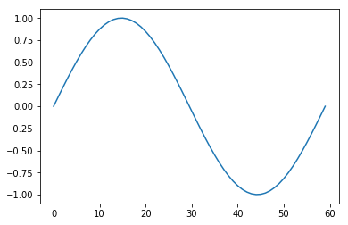

```python
plt.plot(np.sin(t))
```

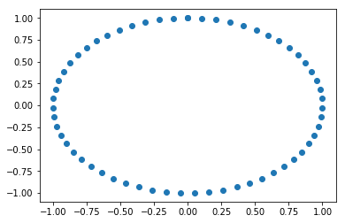

```python
plt.plot(np.sin(t),np.cos(t),'o')
```

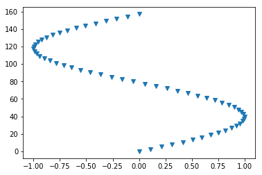

```python
plt.plot(np.sin(t),25*t,'v')
```

```python
 Expliquez la différence entre plt.plot(a) et plt.plot(a,b).
La différence c''est que plt.plot(a,b) donne un graphique en "deux dimention", c'est a dire que sur l'axe "x" on
a la fonction a(t) et sur la axe "y"  la fonction b(t) et non a(t) et t.
```

1. Pour gérer des fichiers, on utilise la bibliothèque os. Affichier le chemin absolu du dossier courant et les fichiers que celui-ci contient.

```python
import os
os.path.abspath(os.curdir)
```

```
'C:\\Users\\Fabrice\\Documents\\TD 1'
```

```python
os.listdir()
```

```
['.ipynb_checkpoints',
 'data1',
 'tp1 le bon.html',
 'TP1-20190129.zip',
 'tp1.ipynb']
```

## Ex. 2 : Des vraies données

1. Récupérez le fichier data1.dat sur moodle (les données du TP1 dans l’onglet TP). Copiez le dans le répertoire courant. Chargez les données du fichier data1.dat et vérifiez que vous l’avez bien fait.

```python
 arr = np.loadtxt("data1", dtype=float)
```

```python
whos
```

[output not shown]

1. Combien y a t’il d’observations n et de variables p ?

```python
arr.shape
```

```
(410, 46)
```

```python
il y a 410 observations et 46 variables
```

```
  File "<ipython-input-30-f3c89d7ff758>", line 1
    il y a 410 observations et 46 variables
       ^
SyntaxError: invalid syntax
```

1. Nous allons travailler sur la douzième variable. Il faut donc extraire la douzième variable du tableau data1 et affectez la à une variable x. Quelle est la nature de cette variable ?

```python
x = arr[:,11] # faut prendre un de moins
x.shape
```

```
(410,)
```

c'est un tableau à une dimention

1. Calculez la moyenne de la variable x de deux manières différentes.

```python
n =  x.shape[0]
np.sum(x) / n
```

```
8.082926829268292
```

```python
np.mean(x)
```

```
8.082926829268292
```

1. Calculez, à partir des observations de x, $\tilde{\mathbb{R}}(x ≤ 50)$ et la fréquence empirique d’observation de la modalité $50 : \tilde{\mathbb{R}}(x = 50)$

```python
np.sum(x<50) / n
```

```
0.9951219512195122
```

```python
np.sum(x==50) / n
```

```
0.0024390243902439024
```

1. Recherchez des différentes modalités de la variables x

```python
Mx = np.unique(x)
Mx
```

```
array([ 0. ,  1. ,  2. ,  2.5,  3. ,  3.5,  4. ,  4.5,  5. ,  5.5,  6. ,
        6.5,  7. ,  7.5,  8. ,  8.5,  9. , 10. , 10.5, 11. , 11.5, 12. ,
       12.5, 13. , 13.5, 14. , 14.5, 15. , 16. , 17. , 17.5, 18. , 19. ,
       20. , 21. , 23. , 24. , 25. , 26. , 27. , 28. , 30. , 32. , 35. ,
       37.5, 40. , 50. , 60. ])
```

1. Calculez des effectifs par modalité

```python
ni = np.zeros(Mx.shape)
for i in range(len(Mx)):
    ni[i] = np.sum(x==Mx[i])
ni
```

```
array([80., 11., 27.,  4., 24.,  2., 26.,  6., 21.,  1., 21.,  4.,  9.,
        2., 26.,  1.,  3., 32.,  1.,  5.,  1., 15.,  2.,  5.,  1.,  4.,
        1., 18.,  3.,  2.,  1.,  4.,  1., 17.,  1.,  1.,  1.,  7.,  1.,
        1.,  1.,  8.,  1.,  2.,  1.,  2.,  1.,  1.])
```

```python
help(np.zeros)
```

[output not shown]

1. Calculez des effectifs cumulés de chaque modalité, les fréquences et les fréquences cumulées.

```python
Ni = np.cumsum(ni)
fi = ni/n
Fi = (Ni/n)
```

1. Affichez les résultats de vos calculs dans un tableau présentant les modalités, leurs effectifs, effectifs cumulés, puis les fréquences et les fréquences cumulées.

```python
print('--------------------------------------------------------\n')
print(' modalites n_i N_i f_i F_i \n')
print('--------------------------------------------------------\n')

for i in range(len(ni)):
    print(ni[i],'  _  ', Ni[i],'  _  ', fi[i],'  _  ', Fi[i])
```

[output not shown]

1. Affichez la fonction de répartition empirique de la variable x.

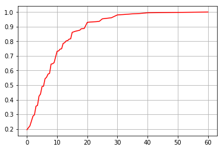

```python
plt.grid(True)
plt.plot(Mx, Fi, '-',color='r')
```

```python
plt.grid sert à avoir le quadrillage
```

```
  File "<ipython-input-49-c732d75f170c>", line 1
    plt.grid sert à avoir le quadrillage
                ^
SyntaxError: invalid syntax
```

```python
help(plt.grid)
```

[output not shown]

[output cut: 17 more lines]

[output not shown]

1. Calculez la médiane de deux manières différentes. En utilisant la fonction NumPy et graphiquement, en utilisant la fonction de répartition empirique que vous venez de dessiner. Pourquoi les résultats sont différents ? Quelle approche vous semble la plus fiable et pourquoi ?

```python
np.median(x)
```

```
6.0
```

```python
help(plt.plot)
```

[output not shown]

[output cut: 221 more lines]

[output not shown]

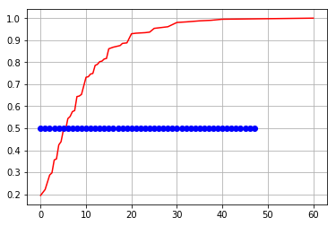

```python
plt.grid(True)
plt.plot(Mx, Fi, '-',color='r')
d=0.5
for i in range(len(Mx)):
    plt.plot(i, d, 'o', color='b')
```

```python
Graphiquement on obtient une médianne d'environ 6/7

la méthode np.median semble plus efficace car la méthode graphique admet une incertitude de lecture, sur les axes, non négligeable.
```

```
  File "<ipython-input-56-40c98f8c0cd1>", line 1
    Graphiquement on obtient une médianne d'environ 6/7
                   ^
SyntaxError: invalid syntax
```

1. Visualisez les fréquences observées de trois manières différentes. A l’aide d’un histogramme standard à 10, un histogramme détaillé à 50, et en affichant les effectifs pour chacune des modalités. La quelle de ces trois vue vous parait la plus intéressante ?

```
<StemContainer object of 3 artists>
```

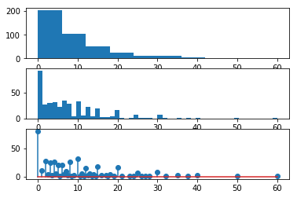

```python
plt.subplot(3,1,1)
plt.hist(x)
plt.subplot(3,1,2)
plt.hist(x,50)
plt.subplot(3,1,3)
plt.stem(Mx,ni)
```

```python
help(plt.hist)
```

[output not shown]

[output cut: 161 more lines]

[output not shown]

```python
help(plt.stem)
```

[output not shown]

[output cut: 30 more lines]

[output not shown]

1. Quelle est la variable du tableau qui a la plus petite moyenne

```python
v = np.min(np.mean(arr, axis=0))
ind = np.argmin(np.mean(arr, axis=0))
print("Index: ", ind, ", Value: ", v)
```

```
Index:  9 , Value:  0.08536585365853659
```

```python
mean permet d'avoir la moyenne
```

```
  File "<ipython-input-62-161cfd329310>", line 1
    mean permet d'avoir la moyenne
              ^
SyntaxError: invalid syntax
```

1. Quelle est la nature des 15 premières variables ?

```python
les 10 premières variables sont des variables qualitatives, les 5 suivantes sont quantitatives
```

1. Les données sur lesquelles vous avez travaillé sont expliquées à cette adresse : http://www.stat.ucla.edu/projects/datasets/fastfood-explanation.html . Il s’agit d’informations sur 410 restaurants choisis au hasard dans le New Jersey et la Pennsylvanie orientale. Pour chaque restaurant nous disposons de 46 variables. Environ la moitié se rapportent à une période avant une augmentation du salaire minimum et l’autre moitié concernent la période postérieure. Les données ci-joints ont été utilisés pour étudier les effets de l’augmentation du salaire minimum sur le chômage.

La douzième variable donne le nombre d’employés (à plein temps) du restaurant.

1. Refaites la même étude avec le montant habituel de la première augmentation (en \$ par heure).

```python
u = arr[:,16]
u.shape
print("u =", u)
```

```
u = [0.   0.   0.37 0.1  0.15 0.07 0.1  0.25 0.25 0.15 0.37 0.17 0.25 0.3
 0.37 0.25 0.07 0.17 0.25 0.37 0.12 0.25 0.25 0.17 0.07 0.25 0.2  0.25
 0.   0.15 0.2  0.   0.25 0.17 0.2  0.   0.15 0.07 0.15 0.1  0.1  0.12
 0.15 0.15 0.15 0.25 0.17 0.07 0.15 0.25 0.25 0.37 0.25 0.25 0.   0.15
 0.15 0.37 0.3  0.   0.   0.5  0.   0.12 0.12 0.22 0.37 0.37 0.25 0.15
 0.1  0.37 0.12 0.25 0.15 0.25 0.12 0.   0.2  0.   0.   0.   0.   0.15
 0.   0.   0.   0.   0.   0.27 0.2  0.   0.32 0.25 0.17 0.15 0.25 0.25
 0.   0.37 0.37 0.15 0.25 0.17 0.15 0.15 0.1  0.37 0.25 0.52 0.17 0.25
 0.27 0.2  0.15 0.05 0.37 0.   0.25 0.15 0.15 0.25 0.17 0.1  0.67 0.25
 0.15 0.15 0.1  0.27 0.25 0.52 0.52 0.12 0.2  0.25 0.   0.25 0.37 0.25
 0.   0.25 0.17 0.1  0.2  0.12 0.25 0.25 0.   0.36 0.12 0.25 0.2  0.15
 0.12 0.17 0.15 0.25 0.   0.2  0.15 0.25 0.25 0.1  0.5  0.15 0.32 0.15
 0.   0.25 0.5  0.25 0.25 0.17 0.15 0.15 0.17 0.1  0.1  0.25 0.15 0.25
 0.25 0.   0.25 0.1  0.12 0.12 0.25 0.25 0.25 0.25 0.   0.25 0.15 0.
 0.2  0.25 0.15 0.25 0.05 0.22 0.27 0.25 0.75 0.25 0.2  0.15 0.25 0.15
 0.25 0.   0.   0.15 0.75 0.15 0.27 0.12 0.25 0.4  0.15 0.15 0.2  0.32
 0.   0.27 0.32 0.37 0.42 0.57 0.3  0.37 0.15 0.27 0.   0.2  0.25 0.25
 0.3  0.25 0.   0.   0.27 0.15 0.37 0.27 0.15 0.25 0.27 0.27 0.25 0.12
 0.12 0.17 0.25 0.25 0.25 0.25 0.15 0.15 0.12 0.2  0.25 0.25 0.25 0.33
 0.2  0.15 0.2  0.17 0.12 0.   0.12 0.12 0.2  0.35 0.37 0.15 0.27 0.25
 0.15 0.12 0.17 0.   0.17 0.15 0.25 0.2  0.15 0.17 0.25 0.12 0.25 0.25
 0.25 0.25 0.2  0.25 0.2  0.1  0.1  0.12 0.32 0.21 0.25 0.12 0.25 0.25
 0.25 0.1  0.37 0.25 0.3  0.   0.2  0.15 0.17 0.25 0.25 0.15 0.22 0.12
 0.2  0.25 0.25 0.25 0.13 0.25 0.25 0.25 0.17 0.25 0.2  0.1  0.12 0.12
 0.12 0.05 0.27 0.37 0.   0.5  0.25 0.22 0.25 0.25 0.25 0.17 0.25 0.12
 0.15 0.25 0.2  0.2  0.3  0.37 0.1  0.25 0.25 0.2  0.2  0.37 0.   0.25
 0.22 0.15 0.17 0.15 0.22 0.66 0.18 0.12 0.25 0.15 0.12 0.25 0.1  0.15
 0.17 0.2  0.25 0.25 0.15 0.25 0.12 0.25 0.37 0.62 0.15 0.3  0.5  0.17
 0.25 0.12 0.1  0.1  0.37 0.5  0.   0.   0.2  0.1  0.5  0.37 0.25 0.5
 0.25 0.15 0.1  0.12]
```

```python
np.mean(u)
```

```
0.20165853658536587
```

```python
Mu = np.unique(u)
Mu
```

```
array([0.  , 0.05, 0.07, 0.1 , 0.12, 0.13, 0.15, 0.17, 0.18, 0.2 , 0.21,
       0.22, 0.25, 0.27, 0.3 , 0.32, 0.33, 0.35, 0.36, 0.37, 0.4 , 0.42,
       0.5 , 0.52, 0.57, 0.62, 0.66, 0.67, 0.75])
```

```python
ni = np.zeros(Mu.shape)
for i in range(len(Mu)):
    ni[i] = np.sum(u==Mu[i])
ni
```

```
array([ 43.,   3.,   5.,  23.,  33.,   1.,  59.,  24.,   1.,  30.,   1.,
         6., 109.,  13.,   7.,   5.,   1.,   1.,   1.,  25.,   1.,   1.,
         8.,   3.,   1.,   1.,   1.,   1.,   2.])
```

```python
Ni = np.cumsum(ni)
fi = ni/n
Fi = (Ni/n)
```

```python
print('--------------------------------------------------------\n')
print(' modalites n_i N_i f_i F_i \n')
print('--------------------------------------------------------\n')

for i in range(len(ni)):
    print(ni[i],'  _  ', Ni[i],'  _  ', fi[i],'  _  ', Fi[i])
```

```
--------------------------------------------------------

 modalites n_i N_i f_i F_i

--------------------------------------------------------

43.0   _   43.0   _   0.1048780487804878   _   0.1048780487804878
3.0   _   46.0   _   0.007317073170731708   _   0.11219512195121951
5.0   _   51.0   _   0.012195121951219513   _   0.12439024390243902
23.0   _   74.0   _   0.05609756097560976   _   0.18048780487804877
33.0   _   107.0   _   0.08048780487804878   _   0.26097560975609757
1.0   _   108.0   _   0.0024390243902439024   _   0.2634146341463415
59.0   _   167.0   _   0.14390243902439023   _   0.4073170731707317
24.0   _   191.0   _   0.05853658536585366   _   0.4658536585365854
1.0   _   192.0   _   0.0024390243902439024   _   0.4682926829268293
30.0   _   222.0   _   0.07317073170731707   _   0.5414634146341464
1.0   _   223.0   _   0.0024390243902439024   _   0.5439024390243903
6.0   _   229.0   _   0.014634146341463415   _   0.5585365853658537
109.0   _   338.0   _   0.2658536585365854   _   0.824390243902439
13.0   _   351.0   _   0.03170731707317073   _   0.8560975609756097
7.0   _   358.0   _   0.01707317073170732   _   0.8731707317073171
5.0   _   363.0   _   0.012195121951219513   _   0.8853658536585366
1.0   _   364.0   _   0.0024390243902439024   _   0.8878048780487805
1.0   _   365.0   _   0.0024390243902439024   _   0.8902439024390244
1.0   _   366.0   _   0.0024390243902439024   _   0.8926829268292683
25.0   _   391.0   _   0.06097560975609756   _   0.9536585365853658
1.0   _   392.0   _   0.0024390243902439024   _   0.9560975609756097
1.0   _   393.0   _   0.0024390243902439024   _   0.9585365853658536
8.0   _   401.0   _   0.01951219512195122   _   0.9780487804878049
3.0   _   404.0   _   0.007317073170731708   _   0.9853658536585366
1.0   _   405.0   _   0.0024390243902439024   _   0.9878048780487805
1.0   _   406.0   _   0.0024390243902439024   _   0.9902439024390244
1.0   _   407.0   _   0.0024390243902439024   _   0.9926829268292683
1.0   _   408.0   _   0.0024390243902439024   _   0.9951219512195122
2.0   _   410.0   _   0.004878048780487805   _   1.0
```

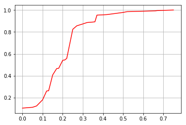

```python
plt.grid(True)
plt.plot(Mu, Fi, '-',color='r')
```

```python
np.median(u)
```

```
0.2
```

```
<StemContainer object of 3 artists>
```

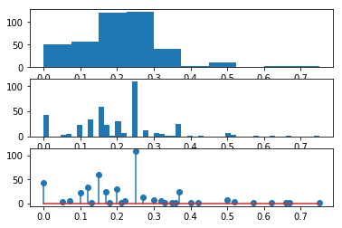

```python
plt.subplot(3,1,1)
plt.hist(u)
plt.subplot(3,1,2)
plt.hist(u,50)
plt.subplot(3,1,3)
plt.stem(Mu,ni)
```

## Rendu de TP

Le rendu qui vous est demandé pour les TP de M8 est la version HTML de ce notebook. Pour l'obtenir: Fichier, télécharger au format, HTML (.html)

```python
Ce tp nous a permis de découvrir le language python tout en travaillant sur des données et leurs signifiactions.
```